# Regression Models: The Vitruvian Man Example

Wednesday, February 11, 2026 @ 06:20 PM

## Are People Squares?

Roman architect [Vitruvius](https://www.ancient.eu/Vitruvius/) wrote that a person’s height is equal to their armspan. Leonardo da Vinci later illustrated this idea.

[figure not shown]

## Our Vitruvian Model

A general model, if we use height to explain / predict armspan…

\[armspan = \beta_0 + \beta_1 (height) + \epsilon\]

If Vitruvius is correct, what is the model’s slope and y-intercept?

\(armspan =\) _____ \(+\) _____ \((height)\)

What would the value of \(\epsilon\) be if all people were perfect squares?

Individual people are likely not perfect squares, but maybe they are squares *on average*, with some amount of random variation for each person. For example, the *average* armspan for everyone 5’9” tall is 5’9”, but some people have longer/shorter armspans.

Or … maybe height and armspan have a different relationship?

## Anthropometric Data

The datafile anthropometric.csv contains measurements from some of Dr. Thomley’s previous stats students ([description](https://stat-jet-asu.github.io/Datasets/InstructorDescriptions/anthropometric.html)).

```r
glimpse(anthro)
```

```
Rows: 547
Columns: 9
$ gender   <chr> "female", "female", "female", "female", "female", "female", "…
$ ideal    <dbl> 64, 64, 65, 63, 68, 64, NA, 65, 66, 63, 62, 60, 65, 68, 64, 6…
$ height   <dbl> 59.75, 59.75, 60.00, 60.00, 60.00, 60.00, 60.50, 60.50, 61.00…
$ armspan  <dbl> 58.5, 58.5, 61.0, 58.0, 62.0, 60.0, 60.0, 61.5, 63.0, 59.0, 6…
$ forearm  <dbl> 15.00, 15.00, 16.00, 15.00, 15.00, 15.00, 15.50, 15.00, 16.50…
$ hand     <dbl> 6.50, 6.50, 7.00, 6.25, 6.00, 6.00, 5.50, 7.00, 7.00, 6.00, 6…
$ leg      <dbl> 16.00, 16.00, 16.00, 16.25, 18.00, 16.00, 17.75, 16.50, 19.00…
$ foot     <dbl> 8.50, 8.50, 8.50, 9.50, 9.00, 8.00, 8.50, 8.50, 9.50, 8.75, 8…
$ semester <chr> "F15", "F15", "F13", "F15", "S13", "Sum13", "S14", "Sum14", "…
```

## Take a Sample

The dataset is large, so let’s take a smaller sample to start with. The `sample_n` function comes from `dplyr`. Setting a seed value ensures we all have the same “random” sample.

```r
set.seed(1)
anthro_sample <- sample_n(anthro, 20)
head(anthro_sample)
```

```
  gender ideal height armspan forearm hand  leg foot semester
1 female 64.50  64.50    67.5   17.25 7.50 19.0  9.5    Sum15
2   male 78.00  74.25    78.0   21.50 8.00 17.5 13.0      S14
3   male 75.00  73.00    72.0   20.00 7.00 18.0  8.0      S13
4   male 72.25  68.50    69.0   18.00 7.25 17.0  9.5      S14
5   male 70.00  68.00    67.0   18.50 7.50 20.0 10.0      S13
6 female 66.00  66.00    65.0   16.50 7.00 20.0 10.0      S13
```

## EDA First!

Do exploratory data analysis (EDA) on the x and y variables to investigate the shape, center, spread, and outliers. Also make a scatterplot and calculate the Pearson correlation.

[figure not shown]

## Boxplot of Height

Are there any univariate outliers for `height` in this sample?

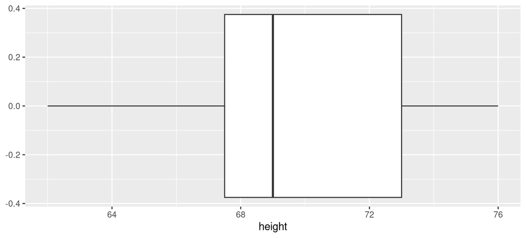

```r
ggplot(anthro_sample, aes(x = height)) +
  geom_boxplot()
```

## Boxplot of Armspan

Are there any univariate outliers for `armspan` in this sample?

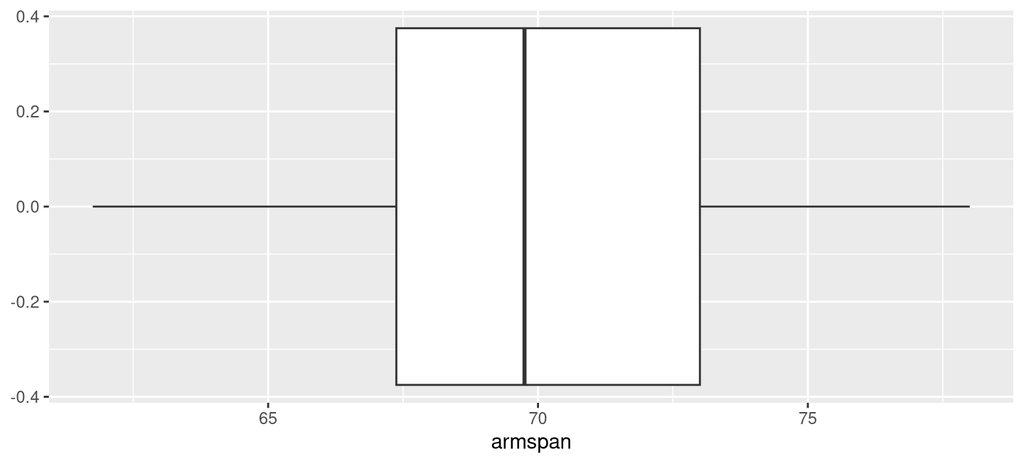

```r
ggplot(anthro_sample, aes(x = armspan)) +
  geom_boxplot()
```

## Scatterplot

Are there any potential *bivariate* outliers in this sample?

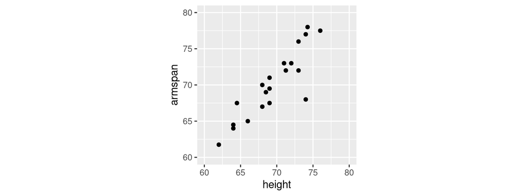

```r
# using coord_fixed because x and y have the same scale
ggplot(anthro_sample, aes(x = height, y = armspan)) +
  geom_point() +
  coord_fixed(xlim = c(60, 80), ylim = c(60, 80)) +
  theme()
```

## Pearson Correlation

We can use the `cor()` function inside `summarize()`.

```r
anthro_sample %>%
  summarize(correlation = cor(height, armspan))
```

```
  correlation
1   0.8853907
```

The `moderndive` package also has a function using `y ~ x`.

```r
anthro_sample %>%
  get_correlation(armspan ~ height)
```

```
        cor
1 0.8853907
```

## Scatterplot with Fitted Line

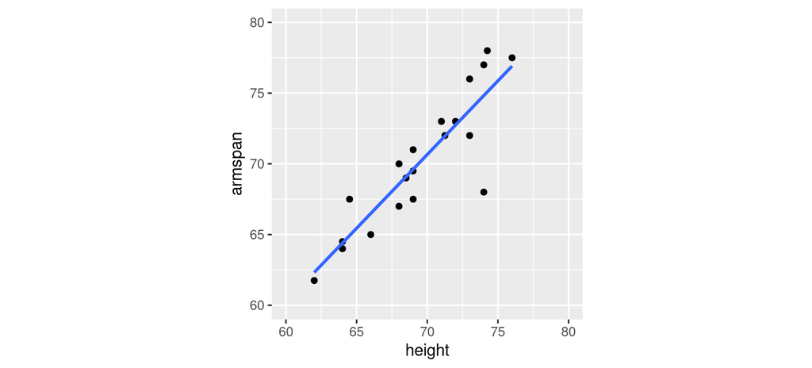

```r
ggplot(anthro_sample, aes(x = height, y = armspan)) +
  geom_point() +
  geom_smooth(method = "lm", se = FALSE) +
  coord_fixed(xlim = c(60, 80), ylim = c(60, 80))
```

## Visualize the Residuals

The dashed lines on the scatterplot represent \(\bar{x}\) and \(\bar{y}\).

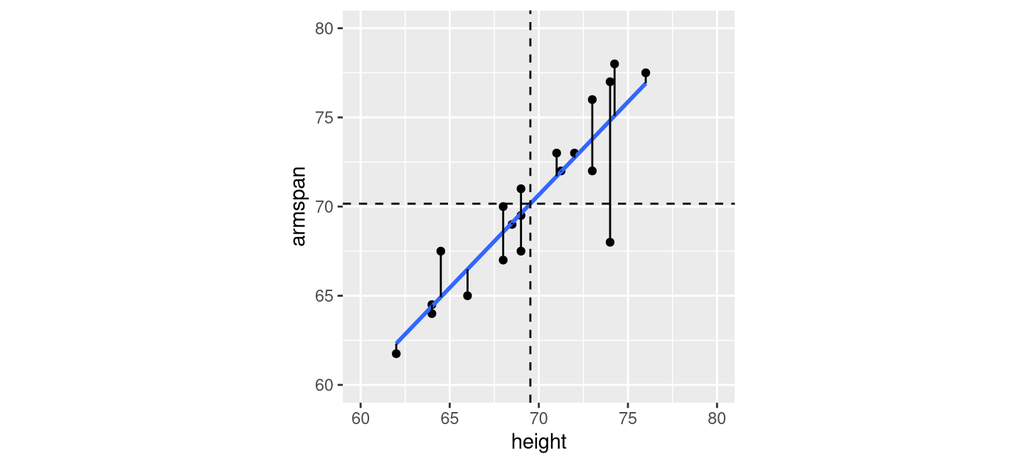

```
 [1] -0.571  0.095 -0.405  2.574 -1.489 -1.573  1.427 -0.094 -2.115 -0.115
[11]  1.385  1.300  0.040  0.258 -1.784  2.216  2.174 -6.826  2.914  0.590
```

## Scatterplot with Fitted & Plotted Lines

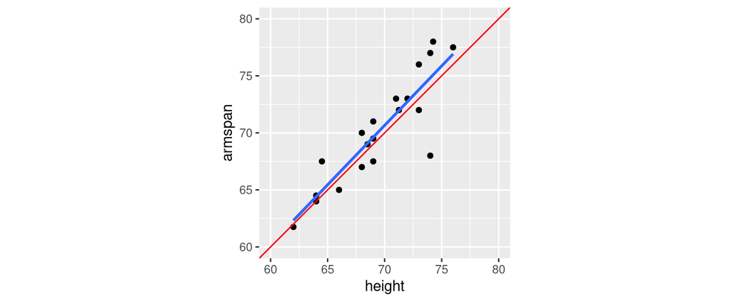

```r
ggplot(anthro_sample, aes(x = height, y = armspan)) +
  geom_point() +
  geom_smooth(method = "lm", se = FALSE) +               # fitted line
  geom_abline(intercept = 0, slope = 1, color = "red") + # theoretical
  coord_fixed(xlim = c(60, 80), ylim = c(60, 80))
```

## Different Samples, Varying Estimates

```r
# there are more efficient ways to do this, notice the pattern

size_n <- 20

sample01 <- sample_n(anthro, size_n) %>% mutate(samplenum = "S01")
sample02 <- sample_n(anthro, size_n) %>% mutate(samplenum = "S02")
sample03 <- sample_n(anthro, size_n) %>% mutate(samplenum = "S03")
sample04 <- sample_n(anthro, size_n) %>% mutate(samplenum = "S04")
sample05 <- sample_n(anthro, size_n) %>% mutate(samplenum = "S05")
sample06 <- sample_n(anthro, size_n) %>% mutate(samplenum = "S06")
sample07 <- sample_n(anthro, size_n) %>% mutate(samplenum = "S07")
sample08 <- sample_n(anthro, size_n) %>% mutate(samplenum = "S08")

eightsamps <- rbind(sample01, sample02, sample03, sample04,
                    sample05, sample06, sample07, sample08)
```

## Plotting All the Estimated Lines

Each sample yields a different estimate, but similar in slope.

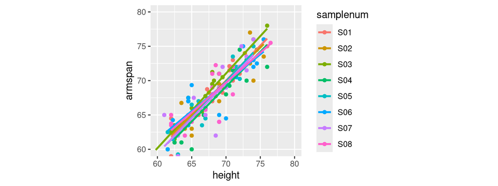

```r
ggplot(eightsamps, aes(x = height, y = armspan, color = samplenum)) +
  geom_point() +
  geom_smooth(method = "lm", se = FALSE) +
  coord_fixed(xlim = c(60, 80), ylim = c(60, 80))
```

## Fitting the Linear Model

The `lm()` function fits the least squares model and computes many related statistics. Far more information is computed and stored than the output that is displayed by default.

```r
square_model <- lm(armspan ~ height, data = anthro_sample)

# default output is the regression coefficients b0 and b1
square_model
```

```
Call:
lm(formula = armspan ~ height, data = anthro_sample)

Coefficients:
(Intercept)       height
     -2.286        1.042
```

```r
summary(square_model) # summary() gives us more output
```

```
Call:
lm(formula = armspan ~ height, data = anthro_sample)

Residuals:
    Min      1Q  Median      3Q     Max
-6.8257 -0.8007  0.0674  1.3951  2.9138

Coefficients:
            Estimate Std. Error t value Pr(>|t|)
(Intercept)   -2.286      8.979  -0.255    0.802
height         1.042      0.129   8.081 2.12e-07 ***
---
Signif. codes:  0 '***' 0.001 '**' 0.01 '*' 0.05 '.' 0.1 ' ' 1

Residual standard error: 2.239 on 18 degrees of freedom
Multiple R-squared:  0.7839,    Adjusted R-squared:  0.7719
F-statistic:  65.3 on 1 and 18 DF,  p-value: 2.123e-07
```

The `lm()` function produces a `list` as output. We can access the components using the `$` notation.

```r
str(square_model)
```

```
List of 12
 $ coefficients : Named num [1:2] -2.29 1.04
  ..- attr(*, "names")= chr [1:2] "(Intercept)" "height"
 $ residuals    : Named num [1:20] 2.5738 2.9138 -1.7836 -0.0944 -1.5734 ...
  ..- attr(*, "names")= chr [1:20] "1" "2" "3" "4" ...
 $ effects      : Named num [1:20] -313.776 -18.097 -2.72 -0.553 -1.979 ...
  ..- attr(*, "names")= chr [1:20] "(Intercept)" "height" "" "" ...
 $ rank         : int 2
 $ fitted.values: Named num [1:20] 64.9 75.1 73.8 69.1 68.6 ...
  ..- attr(*, "names")= chr [1:20] "1" "2" "3" "4" ...
 $ assign       : int [1:2] 0 1
 $ qr           :List of 5
  ..$ qr   : num [1:20, 1:2] -4.472 0.224 0.224 0.224 0.224 ...
  .. ..- attr(*, "dimnames")=List of 2
  .. .. ..$ : chr [1:20] "1" "2" "3" "4" ...
  .. .. ..$ : chr [1:2] "(Intercept)" "height"
  .. ..- attr(*, "assign")= int [1:2] 0 1
  ..$ qraux: num [1:2] 1.22 1.32
  ..$ pivot: int [1:2] 1 2
  ..$ tol  : num 1e-07
  ..$ rank : int 2
  ..- attr(*, "class")= chr "qr"
 $ df.residual  : int 18
 $ xlevels      : Named list()
 $ call         : language lm(formula = armspan ~ height, data = anthro_sample)
 $ terms        :Classes 'terms', 'formula'  language armspan ~ height
  .. ..- attr(*, "variables")= language list(armspan, height)
  .. ..- attr(*, "factors")= int [1:2, 1] 0 1
  .. .. ..- attr(*, "dimnames")=List of 2
  .. .. .. ..$ : chr [1:2] "armspan" "height"
  .. .. .. ..$ : chr "height"
  .. ..- attr(*, "term.labels")= chr "height"
  .. ..- attr(*, "order")= int 1
  .. ..- attr(*, "intercept")= int 1
  .. ..- attr(*, "response")= int 1
  .. ..- attr(*, ".Environment")=<environment: R_GlobalEnv>
  .. ..- attr(*, "predvars")= language list(armspan, height)
  .. ..- attr(*, "dataClasses")= Named chr [1:2] "numeric" "numeric"
  .. .. ..- attr(*, "names")= chr [1:2] "armspan" "height"
 $ model        :'data.frame':  20 obs. of  2 variables:
  ..$ armspan: num [1:20] 67.5 78 72 69 67 65 67.5 70 77 69.5 ...
  ..$ height : num [1:20] 64.5 74.2 73 68.5 68 ...
  ..- attr(*, "terms")=Classes 'terms', 'formula'  language armspan ~ height
  .. .. ..- attr(*, "variables")= language list(armspan, height)
  .. .. ..- attr(*, "factors")= int [1:2, 1] 0 1
  .. .. .. ..- attr(*, "dimnames")=List of 2
  .. .. .. .. ..$ : chr [1:2] "armspan" "height"
  .. .. .. .. ..$ : chr "height"
  .. .. ..- attr(*, "term.labels")= chr "height"
  .. .. ..- attr(*, "order")= int 1
  .. .. ..- attr(*, "intercept")= int 1
  .. .. ..- attr(*, "response")= int 1
  .. .. ..- attr(*, ".Environment")=<environment: R_GlobalEnv>
  .. .. ..- attr(*, "predvars")= language list(armspan, height)
  .. .. ..- attr(*, "dataClasses")= Named chr [1:2] "numeric" "numeric"
  .. .. .. ..- attr(*, "names")= chr [1:2] "armspan" "height"
 - attr(*, "class")= chr "lm"
```

## Accessing Output Components

```r
square_model$coefficients
```

```
(Intercept)      height
  -2.285668    1.042045
```

```r
square_model$residuals
```

```
          1           2           3           4           5           6
 2.57377533  2.91383812 -1.78360583 -0.09440404 -1.57338162 -1.48929193
          7           8           9          10          11          12
-2.11542646  1.42661838  2.17434933 -0.11542646 -0.57111256  0.09479775
         13          14          15          16          17          18
 2.21639417  1.30048386  1.38457354  0.59025965  0.25843902 -0.40520225
         19          20
 0.03997265 -6.82565067
```

## Coefficients with Modern Dive

The package `moderndive` contains some “wrapper” functions to help easily access and format regression output for information and additional analysis. Default format is three sig. figures.

```r
square_model_table <- get_regression_table(square_model)

square_model_table
```

```
# A tibble: 2 × 7
  term      estimate std_error statistic p_value lower_ci upper_ci
  <chr>        <dbl>     <dbl>     <dbl>   <dbl>    <dbl>    <dbl>
1 intercept    -2.29     8.98     -0.255   0.802  -21.2      16.6
2 height        1.04     0.129     8.08    0        0.771     1.31
```

This output is a `tibble`. Why is this potentially useful to us?

## Formatting with Modern Dive

We can also print the results in a formatted Markdown version. It looks different in reports versus slides. You can do more with `kable.styling()` from the `kableExtra` package.

```r
get_regression_table(square_model, digits = 2, print = TRUE)
```

| term | estimate | std_error | statistic | p_value | lower_ci | upper_ci |
| --- | --- | --- | --- | --- | --- | --- |
| intercept | -2.29 | 8.98 | -0.25 | 0.8 | -21.15 | 16.58 |
| height | 1.04 | 0.13 | 8.08 | 0.0 | 0.77 | 1.31 |

The CIs help estimate the true values of the slope and intercept for the population versus just our data. (*We will dive more deeply into CIs later in the course.*)

## Formatting with `kable()`

The `select()` and `kable()` functions give us somewhat more control of the output. It looks different in reports versus slides.

```r
library(knitr)
get_regression_table(square_model) %>%
  select(term, estimate, std_error) %>%
  kable(digits = 2)
```

| term | estimate | std_error |
| --- | --- | --- |
| intercept | -2.29 | 8.98 |
| height | 1.04 | 0.13 |

## Model Summaries for Vitruvian Model

There are additional summaries that help us interpret and make predictions using the fitted linear model.

```r
get_regression_summaries(square_model) %>%
  select(r_squared, mse, rmse, sigma) %>%
  kable(digits = 2, align = "cccc",
        caption = "Vitruvian Man Model Summaries")
```

Vitruvian Man Model Summaries

| r_squared | mse | rmse | sigma |
| --- | --- | --- | --- |
| 0.78 | 4.51 | 2.12 | 2.24 |

Tutorial for `kableExtra`: https://rpubs.com/yutao/444395

## Fitted Values and Residuals

You can get the fitted values and residuals individually from the saved `lm()`, but the `get_regression_points()` accesses these values and formats them into a `tibble` (dataset).

```r
square_model_residuals <- get_regression_points(square_model)
head(square_model_residuals)
```

```
# A tibble: 6 × 5
     ID armspan height armspan_hat residual
  <int>   <dbl>  <dbl>       <dbl>    <dbl>
1     1    67.5   64.5        64.9    2.57
2     2    78     74.2        75.1    2.91
3     3    72     73          73.8   -1.78
4     4    69     68.5        69.1   -0.094
5     5    67     68          68.6   -1.57
6     6    65     66          66.5   -1.49
```

## Predicting Armspan for New Heights

The data points we want to use for prediction need to be in a dataset with the same variable names as our model `x` values.

```r
data_for_prediction <- tibble(height = c(60, 69, 72))
```

Then use `get_regression_points()` to make the predictions, with the `newdata` option set to our new dataset.

```r
get_regression_points(square_model, newdata = data_for_prediction)
```

```
# A tibble: 3 × 3
     ID height armspan_hat
  <int>  <dbl>       <dbl>
1     1     60        60.2
2     2     69        69.6
3     3     72        72.7
```